# HR Analysis

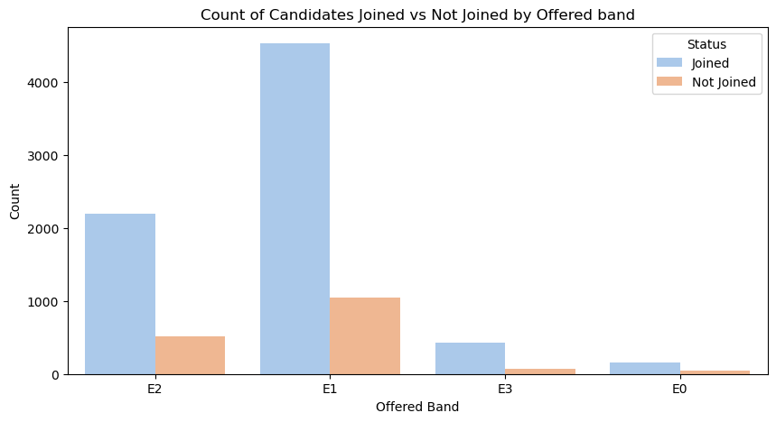

```python
plt.figure(figsize=(10, 5))
sn.countplot(data=df, x='Offered band', hue='Status', palette='pastel')
plt.title('Count of Candidates Joined vs Not Joined by Offered band')
plt.xlabel('Offered Band')
plt.ylabel('Count')
plt.show()
```

### Band-wise Comparison:

#### -->E1: The highest number of candidates joined in the E1 band, followed by E2.

#### -->E2: While the number of joined candidates is high, it's significantly lower than E1.

#### -->E3, EO: These bands show relatively lower numbers of candidates in both joined and not joined categories.

### Copy the df data to Data

```python
data=df.copy()
```

```python
data
```

|  | Sno | Candidate Ref | DOJ Extended | Duration to accept offer | Notice period | Offered band | Percent hike expected in CTC | Percent hike offered in CTC | Percent difference CTC | Joining Bonus | Candidate relocate actual | Gender | Candidate Source | Rex in Yrs | Location | Age | LOB_id | LOB | Status |
| --- | --- | --- | --- | --- | --- | --- | --- | --- | --- | --- | --- | --- | --- | --- | --- | --- | --- | --- | --- |
| 0 | 1 | 2110407 | Yes | 14 | 30 | E2 | 20.79 | 13.16 | 7.63 | No | No | Female | Agency | 7 | Noida | 34.0 | 1 | ERS | Joined |
| 1 | 2 | 2112635 | No | 18 | 30 | E2 | 50.00 | 320.00 | 270.00 | No | No | Male | Employee Referral | 8 | Chennai | 34.0 | 2 | INFRA | Joined |
| 2 | 3 | 2112838 | No | 3 | 45 | E2 | 42.84 | 42.84 | 0.00 | No | No | Male | Agency | 4 | Noida | 27.0 | 2 | INFRA | Joined |
| 3 | 4 | 2115021 | No | 26 | 30 | E2 | 42.84 | 42.84 | 0.00 | No | No | Male | Employee Referral | 4 | Noida | 34.0 | 2 | INFRA | Joined |
| 4 | 5 | 2115125 | Yes | 1 | 120 | E2 | 42.59 | 42.59 | 0.00 | No | Yes | Male | Employee Referral | 6 | Noida | 34.0 | 2 | INFRA | Joined |
| ... | ... | ... | ... | ... | ... | ... | ... | ... | ... | ... | ... | ... | ... | ... | ... | ... | ... | ... | ... |
| 8990 | 12319 | 3822427 | No | 4 | 0 | E1 | 191.67 | 191.67 | 0.00 | No | No | Male | Employee Referral | 1 | Chennai | 34.0 | 1 | ERS | Joined |
| 8991 | 12327 | 3828206 | Yes | 2 | 0 | E1 | 150.00 | 150.00 | 0.00 | No | No | Female | Direct | 3 | Chennai | 34.0 | 4 | BFSI | Joined |
| 8992 | 12331 | 3834159 | No | 0 | 0 | E2 | 35.42 | 35.42 | 0.00 | No | No | Male | Direct | 5 | Noida | 34.0 | 2 | INFRA | Joined |
| 8993 | 12332 | 3835433 | No | 0 | 30 | E1 | 76.92 | 53.85 | 23.07 | No | No | Male | Direct | 4 | Noida | 34.0 | 2 | INFRA | Joined |
| 8994 | 12333 | 3836076 | No | 2 | 0 | E1 | 45.25 | 14.09 | 31.16 | No | No | Female | Employee Referral | 1 | Chennai | 34.0 | 2 | INFRA | Joined |

8995 rows × 19 columns

```python
data.isna().sum()
```

```
Sno                             0
Candidate Ref                   0
DOJ Extended                    0
Duration to accept offer        0
Notice period                   0
Offered band                    0
Percent hike expected in CTC    0
Percent hike offered in CTC     0
Percent difference CTC          0
Joining Bonus                   0
Candidate relocate actual       0
Gender                          0
Candidate Source                0
Rex in Yrs                      0
Location                        0
Age                             0
LOB_id                          0
LOB                             0
Status                          0
dtype: int64
```

## drop columns that are not important for the analysis

```python
data.drop(columns=['Sno','Candidate Ref','LOB_id','Gender'],inplace=True)
```

```python
data.head()
```

|  | DOJ Extended | Duration to accept offer | Notice period | Offered band | Percent hike expected in CTC | Percent hike offered in CTC | Percent difference CTC | Joining Bonus | Candidate relocate actual | Candidate Source | Rex in Yrs | Location | Age | LOB | Status |
| --- | --- | --- | --- | --- | --- | --- | --- | --- | --- | --- | --- | --- | --- | --- | --- |
| 0 | Yes | 14 | 30 | E2 | 20.79 | 13.16 | 7.63 | No | No | Agency | 7 | Noida | 34.0 | ERS | Joined |
| 1 | No | 18 | 30 | E2 | 50.00 | 320.00 | 270.00 | No | No | Employee Referral | 8 | Chennai | 34.0 | INFRA | Joined |
| 2 | No | 3 | 45 | E2 | 42.84 | 42.84 | 0.00 | No | No | Agency | 4 | Noida | 27.0 | INFRA | Joined |
| 3 | No | 26 | 30 | E2 | 42.84 | 42.84 | 0.00 | No | No | Employee Referral | 4 | Noida | 34.0 | INFRA | Joined |
| 4 | Yes | 1 | 120 | E2 | 42.59 | 42.59 | 0.00 | No | Yes | Employee Referral | 6 | Noida | 34.0 | INFRA | Joined |

## import label encoder

### --> Label Encoder converts categorical values into integers

```python
from sklearn.preprocessing import LabelEncoder
le=LabelEncoder()
```

```python
data['DOJ Extended']=le.fit_transform(data['DOJ Extended'])
data['Offered band']=le.fit_transform(data['Offered band'])
data['Joining Bonus']=le.fit_transform(data['Joining Bonus'])
data['Candidate relocate actual']=le.fit_transform(data['Candidate relocate actual'])
data['Candidate Source']=le.fit_transform(data['Candidate Source'])
data['Location']=le.fit_transform(data['Location'])
data['LOB']=le.fit_transform(data['LOB'])
data['Status']=le.fit_transform(data['Status'])
```

```python
data.head()
```

|  | DOJ Extended | Duration to accept offer | Notice period | Offered band | Percent hike expected in CTC | Percent hike offered in CTC | Percent difference CTC | Joining Bonus | Candidate relocate actual | Candidate Source | Rex in Yrs | Location | Age | LOB | Status |
| --- | --- | --- | --- | --- | --- | --- | --- | --- | --- | --- | --- | --- | --- | --- | --- |
| 0 | 1 | 14 | 30 | 2 | 20.79 | 13.16 | 7.63 | 0 | 0 | 0 | 7 | 8 | 34.0 | 4 | 0 |
| 1 | 0 | 18 | 30 | 2 | 50.00 | 320.00 | 270.00 | 0 | 0 | 2 | 8 | 2 | 34.0 | 7 | 0 |
| 2 | 0 | 3 | 45 | 2 | 42.84 | 42.84 | 0.00 | 0 | 0 | 0 | 4 | 8 | 27.0 | 7 | 0 |
| 3 | 0 | 26 | 30 | 2 | 42.84 | 42.84 | 0.00 | 0 | 0 | 2 | 4 | 8 | 34.0 | 7 | 0 |
| 4 | 1 | 1 | 120 | 2 | 42.59 | 42.59 | 0.00 | 0 | 1 | 2 | 6 | 8 | 34.0 | 7 | 0 |

### Describe the Correlation b/w the columns

```python
round(data.corr(),2)*100
```

|  | DOJ Extended | Duration to accept offer | Notice period | Offered band | Percent hike expected in CTC | Percent hike offered in CTC | Percent difference CTC | Joining Bonus | Candidate relocate actual | Candidate Source | Rex in Yrs | Location | Age | LOB | Status |
| --- | --- | --- | --- | --- | --- | --- | --- | --- | --- | --- | --- | --- | --- | --- | --- |
| DOJ Extended | 100.0 | 34.0 | 14.0 | 6.0 | -0.0 | -1.0 | -0.0 | 7.0 | 2.0 | -0.0 | 10.0 | -2.0 | 6.0 | -7.0 | -1.0 |
| Duration to accept offer | 34.0 | 100.0 | 36.0 | 4.0 | 1.0 | -0.0 | -1.0 | 3.0 | 1.0 | -5.0 | 11.0 | -13.0 | 2.0 | -19.0 | 7.0 |
| Notice period | 14.0 | 36.0 | 100.0 | 15.0 | -1.0 | -3.0 | -2.0 | 2.0 | -7.0 | -4.0 | 18.0 | -2.0 | -1.0 | -13.0 | 19.0 |
| Offered band | 6.0 | 4.0 | 15.0 | 100.0 | -17.0 | -4.0 | 5.0 | 8.0 | 1.0 | 14.0 | 71.0 | 12.0 | 44.0 | 22.0 | -2.0 |
| Percent hike expected in CTC | -0.0 | 1.0 | -1.0 | -17.0 | 100.0 | 67.0 | 24.0 | -4.0 | 0.0 | -3.0 | -22.0 | -8.0 | -14.0 | -1.0 | -0.0 |
| Percent hike offered in CTC | -1.0 | -0.0 | -3.0 | -4.0 | 67.0 | 100.0 | 55.0 | -4.0 | 1.0 | -0.0 | -12.0 | -4.0 | -8.0 | 9.0 | -3.0 |
| Percent difference CTC | -0.0 | -1.0 | -2.0 | 5.0 | 24.0 | 55.0 | 100.0 | 0.0 | 0.0 | -2.0 | -0.0 | 1.0 | -0.0 | 8.0 | 2.0 |
| Joining Bonus | 7.0 | 3.0 | 2.0 | 8.0 | -4.0 | -4.0 | 0.0 | 100.0 | 10.0 | 1.0 | 12.0 | -1.0 | 11.0 | -10.0 | 0.0 |
| Candidate relocate actual | 2.0 | 1.0 | -7.0 | 1.0 | 0.0 | 1.0 | 0.0 | 10.0 | 100.0 | 1.0 | -1.0 | 4.0 | 5.0 | 2.0 | -20.0 |
| Candidate Source | -0.0 | -5.0 | -4.0 | 14.0 | -3.0 | -0.0 | -2.0 | 1.0 | 1.0 | 100.0 | 8.0 | 17.0 | 6.0 | 14.0 | -11.0 |
| Rex in Yrs | 10.0 | 11.0 | 18.0 | 71.0 | -22.0 | -12.0 | -0.0 | 12.0 | -1.0 | 8.0 | 100.0 | -4.0 | 57.0 | -11.0 | 4.0 |
| Location | -2.0 | -13.0 | -2.0 | 12.0 | -8.0 | -4.0 | 1.0 | -1.0 | 4.0 | 17.0 | -4.0 | 100.0 | -2.0 | 32.0 | -9.0 |
| Age | 6.0 | 2.0 | -1.0 | 44.0 | -14.0 | -8.0 | -0.0 | 11.0 | 5.0 | 6.0 | 57.0 | -2.0 | 100.0 | -8.0 | -5.0 |
| LOB | -7.0 | -19.0 | -13.0 | 22.0 | -1.0 | 9.0 | 8.0 | -10.0 | 2.0 | 14.0 | -11.0 | 32.0 | -8.0 | 100.0 | -11.0 |
| Status | -1.0 | 7.0 | 19.0 | -2.0 | -0.0 | -3.0 | 2.0 | 0.0 | -20.0 | -11.0 | 4.0 | -9.0 | -5.0 | -11.0 | 100.0 |

```python
x=data.iloc[:,:-1]
```

```python
y=data['Status']
```

# Split the data into training and testing

```python
from sklearn.model_selection import train_test_split
```

```python
xtrain,xtest,ytrain,ytest=train_test_split(x,y,test_size=0.2,random_state=2)
```

```python
xtrain
```

|  | DOJ Extended | Duration to accept offer | Notice period | Offered band | Percent hike expected in CTC | Percent hike offered in CTC | Percent difference CTC | Joining Bonus | Candidate relocate actual | Candidate Source | Rex in Yrs | Location | Age | LOB |
| --- | --- | --- | --- | --- | --- | --- | --- | --- | --- | --- | --- | --- | --- | --- |
| 171 | 1 | 1 | 30 | 3 | 12.20 | 12.20 | 0.00 | 0 | 0 | 2 | 10 | 5 | 36.0 | 7 |
| 8914 | 1 | 14 | 90 | 1 | 35.42 | 29.17 | 6.25 | 0 | 0 | 1 | 5 | 8 | 34.0 | 2 |
| 5601 | 1 | 34 | 30 | 1 | 64.47 | 42.54 | 21.93 | 0 | 1 | 1 | 5 | 1 | 31.0 | 5 |
| 2382 | 0 | 24 | 30 | 2 | 27.66 | 17.02 | 10.64 | 0 | 0 | 0 | 7 | 1 | 35.0 | 1 |
| 2003 | 0 | 13 | 60 | 1 | 95.65 | 84.78 | 10.87 | 0 | 0 | 0 | 4 | 1 | 33.0 | 1 |
| ... | ... | ... | ... | ... | ... | ... | ... | ... | ... | ... | ... | ... | ... | ... |
| 1099 | 0 | 1 | 30 | 2 | 50.00 | 45.00 | 5.00 | 0 | 0 | 1 | 7 | 1 | 30.0 | 2 |
| 2514 | 1 | 16 | 30 | 1 | 100.00 | 100.00 | 0.00 | 0 | 0 | 0 | 3 | 5 | 28.0 | 4 |
| 6637 | 0 | 56 | 60 | 1 | 61.73 | 48.25 | 13.48 | 0 | 0 | 1 | 3 | 2 | 28.0 | 2 |
| 2575 | 1 | 35 | 30 | 1 | 40.63 | 40.63 | 0.00 | 0 | 0 | 0 | 3 | 1 | 25.0 | 1 |
| 7336 | 1 | 3 | 30 | 3 | 36.84 | 34.74 | 2.10 | 0 | 0 | 0 | 9 | 1 | 34.0 | 4 |

7196 rows × 14 columns

# MODEL BUILDING

#### --> HANDLING CLASS IMBALANCE

#### SMOTE (Synthetic Minority Over-sampling Technique) it is an oversampling technique used to address the problem of class imbalance in classification datasets.

```python
from imblearn.over_sampling import SMOTE
```

```python
ytrain.value_counts()
```

```
Status
0    5851
1    1345
Name: count, dtype: int64
```

```python
smote=SMOTE(random_state=2)
```

```python
xtrain_smote,ytrain_smote=smote.fit_resample(xtrain,ytrain)
```

```python
ytrain_smote.value_counts()
```

```
Status
0    5851
1    5851
Name: count, dtype: int64
```

# RANDOMFOREST

```python
from sklearn.ensemble import RandomForestClassifier
```

```python
rf=RandomForestClassifier(n_estimators=50,max_depth=6,random_state=45)
```

```python
rf_model=rf.fit(xtrain,ytrain)
```

```python
rf_pred=rf_model.predict(xtest)
```

```python
from sklearn.metrics import accuracy_score,precision_score,classification_report
```

```python
accuracy_score(ytest,rf_pred)
```

```
0.8148971650917176
```

```python
precision_score(ytest,rf_pred)
```

```
0.8333333333333334
```

```python
pd.crosstab(ytest,rf_pred)
```

| col_0 Status | 0 | 1 |
| --- | --- | --- |
| 0 | 1461 | 1 |
| 1 | 332 | 5 |

```python
print(classification_report(ytest,rf_pred))
```

```
              precision    recall  f1-score   support

           0       0.81      1.00      0.90      1462
           1       0.83      0.01      0.03       337

    accuracy                           0.81      1799
   macro avg       0.82      0.51      0.46      1799
weighted avg       0.82      0.81      0.73      1799
```

```python
rf_model.feature_importances_
```

```
array([0.00845658, 0.14188556, 0.17678124, 0.02063775, 0.03960473,
       0.04097003, 0.07891806, 0.00832955, 0.24600297, 0.03727486,
       0.03908466, 0.04277007, 0.04317817, 0.07610578])
```

```python
xtrain.columns
```

```
Index(['DOJ Extended', 'Duration to accept offer', 'Notice period',
       'Offered band', 'Percent hike expected in CTC',
       'Percent hike offered in CTC', 'Percent difference CTC',
       'Joining Bonus', 'Candidate relocate actual', 'Candidate Source',
       'Rex in Yrs', 'Location', 'Age', 'LOB'],
      dtype='object')
```

# XGB BOOST

```python
from xgboost import XGBClassifier
```

```python
xgb=XGBClassifier(learning_rate=0.05)
```

```python
xgb_model=xgb.fit(xtrain,ytrain)
```

```python
xgb_pred=xgb_model.predict(xtest)
```

```python
accuracy_score(ytest,xgb_pred)
```

```
0.8237909949972206
```

```python
precision_score(ytest,xgb_pred)
```

```
0.6162790697674418
```

```python
pd.crosstab(ytest,xgb_pred)
```

| col_0 Status | 0 | 1 |
| --- | --- | --- |
| 0 | 1429 | 33 |
| 1 | 284 | 53 |

# DECISION TREE

```python
from sklearn.tree import DecisionTreeClassifier
```

```python
from sklearn.model_selection import GridSearchCV
```

```python
tr=DecisionTreeClassifier(max_leaf_nodes=10,max_depth=5,min_samples_split=5,min_samples_leaf=5)
```

```python
tr_model=tr.fit(xtrain,ytrain)
```

```python
tr_pred=tr_model.predict(xtest)
```

```python
accuracy_score(ytest,tr_pred)
```

```
0.8160088938299055
```

```python
precision_score(ytest,tr_pred)
```

```
0.8
```

```python
pd.crosstab(ytest,tr_pred)
```

| col_0 Status | 0 | 1 |
| --- | --- | --- |
| 0 | 1460 | 2 |
| 1 | 329 | 8 |

```python
from sklearn.tree import plot_tree
```

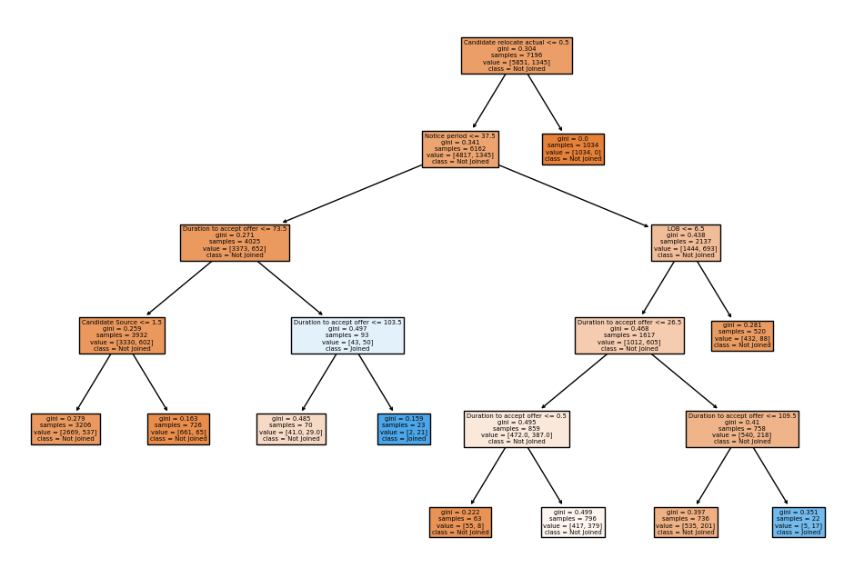

```python
plt.figure(figsize=(12,8))
plot_tree(tr_model,feature_names=xtrain.columns,class_names=['Not Joined','Joined'],filled=True)
plt.show()
```

# LogisticRegression

```python
from sklearn.linear_model import LogisticRegression
```

```python
lr=LogisticRegression(max_iter=500,C=10,solver='liblinear')
```

```python
lr_model=lr.fit(xtrain,ytrain)
```

```python
lr_pred=lr_model.predict(xtest)
```

```python
accuracy_score(ytest,lr_pred)
```

```
0.8143413007226237
```

```python
precision_score(ytest,lr_pred)
```

```
0.5454545454545454
```

#### ---> To detect multi colinearity, we used variance_inflation_factor

```python
from statsmodels.stats.outliers_influence import variance_inflation_factor
```

```python
vif=pd.DataFrame()
```

```python
vif['features']=xtrain.columns
```

```python
xtrain.values
```

```
array([[ 1.,  1., 30., ...,  5., 36.,  7.],
       [ 1., 14., 90., ...,  8., 34.,  2.],
       [ 1., 34., 30., ...,  1., 31.,  5.],
       ...,
       [ 0., 56., 60., ...,  2., 28.,  2.],
       [ 1., 35., 30., ...,  1., 25.,  1.],
       [ 1.,  3., 30., ...,  1., 34.,  4.]])
```

```python
vif["vif_val"]=[variance_inflation_factor(xtrain.values,i) for i in range(len(xtrain.columns))]
```

```python
vif
```

|  | features | vif_val |
| --- | --- | --- |
| 0 | DOJ Extended | 2.119659 |
| 1 | Duration to accept offer | 2.225569 |
| 2 | Notice period | 4.732056 |
| 3 | Offered band | 14.974155 |
| 4 | Percent hike expected in CTC | 6.415729 |
| 5 | Percent hike offered in CTC | 6.510501 |
| 6 | Percent difference CTC | 1.990369 |
| 7 | Joining Bonus | 1.089862 |
| 8 | Candidate relocate actual | 1.196604 |
| 9 | Candidate Source | 2.858213 |
| 10 | Rex in Yrs | 10.155551 |
| 11 | Location | 3.178414 |
| 12 | Age | 17.210870 |
| 13 | LOB | 5.448461 |

# FEATURE SELECTION TECHNIQUES

```python
from sklearn.feature_selection import SelectKBest, chi2
```

```python
sk=SelectKBest(score_func=chi2,k=5)
res_sk=sk.fit(xtrain,ytrain)
```

```python
res_sk.scores_
```

```
array([9.66059052e-02, 9.25867075e+02, 3.19873540e+03, 1.29192954e+00,
       1.90786821e-01, 2.94068511e+02, 3.39897812e+01, 1.95128229e-01,
       2.37690993e+02, 3.99441524e+01, 1.09707872e+01, 1.37177579e+02,
       1.06075629e+01, 1.23537720e+02])
```

```python
for i in res_sk.scores_:
    print(round(i,2))
```

```
0.1
925.87
3198.74
1.29
0.19
294.07
33.99
0.2
237.69
39.94
10.97
137.18
10.61
123.54
```

```python
for i in xtrain.columns:
    print(i)
```

```
DOJ Extended
Duration to accept offer
Notice period
Offered band
Percent hike expected in CTC
Percent hike offered in CTC
Percent difference CTC
Joining Bonus
Candidate relocate actual
Candidate Source
Rex in Yrs
Location
Age
LOB
```

### (Percent hike expected in CTC,Percent hike offered in CTC) can be removed as we have Percent difference CTC column

```python
data.drop(columns=['Percent hike expected in CTC','Percent hike offered in CTC','Age','Location'],inplace=True)
```

```python
data.head(2)
```

|  | DOJ Extended | Duration to accept offer | Notice period | Offered band | Percent difference CTC | Joining Bonus | Candidate relocate actual | Candidate Source | Rex in Yrs | LOB | Status |
| --- | --- | --- | --- | --- | --- | --- | --- | --- | --- | --- | --- |
| 0 | 1 | 14 | 30 | 2 | 7.63 | 0 | 0 | 0 | 7 | 4 | 0 |
| 1 | 0 | 18 | 30 | 2 | 270.00 | 0 | 0 | 2 | 8 | 7 | 0 |

# Now we again split the data into training and testing and build the model

```python
X=data.iloc[:,:-1]
```

```python
X.head(2)
```

|  | DOJ Extended | Duration to accept offer | Notice period | Offered band | Percent difference CTC | Joining Bonus | Candidate relocate actual | Candidate Source | Rex in Yrs | LOB |
| --- | --- | --- | --- | --- | --- | --- | --- | --- | --- | --- |
| 0 | 1 | 14 | 30 | 2 | 7.63 | 0 | 0 | 0 | 7 | 4 |
| 1 | 0 | 18 | 30 | 2 | 270.00 | 0 | 0 | 2 | 8 | 7 |

```python
Y=data['Status']
```

```python
Xtrain,Xtest,Ytrain,Ytest=train_test_split(X,Y,test_size=0.2,random_state=2)
```

```python
Xtest
```

|  | DOJ Extended | Duration to accept offer | Notice period | Offered band | Percent difference CTC | Joining Bonus | Candidate relocate actual | Candidate Source | Rex in Yrs | LOB |
| --- | --- | --- | --- | --- | --- | --- | --- | --- | --- | --- |
| 7982 | 0 | 23 | 30 | 1 | 5.88 | 0 | 0 | 0 | 3 | 4 |
| 8109 | 0 | 30 | 30 | 3 | 144.45 | 0 | 0 | 1 | 5 | 7 |
| 2124 | 0 | 2 | 30 | 1 | 10.81 | 0 | 0 | 0 | 8 | 4 |
| 4174 | 0 | 7 | 30 | 2 | 5.22 | 0 | 0 | 2 | 9 | 1 |
| 8024 | 1 | 6 | 0 | 2 | 30.77 | 1 | 1 | 0 | 6 | 4 |
| ... | ... | ... | ... | ... | ... | ... | ... | ... | ... | ... |
| 2150 | 0 | 3 | 30 | 0 | 0.00 | 0 | 0 | 1 | 0 | 7 |
| 5981 | 1 | 64 | 60 | 1 | 0.00 | 0 | 0 | 0 | 3 | 1 |
| 5044 | 0 | 18 | 90 | 2 | 0.00 | 0 | 0 | 0 | 4 | 7 |
| 876 | 1 | 5 | 30 | 1 | 12.00 | 0 | 0 | 1 | 1 | 7 |
| 8321 | 1 | 2 | 0 | 2 | 4.02 | 1 | 0 | 1 | 7 | 0 |

1799 rows × 10 columns

### call RandomForestClassifier

```python
rf
```

```
RandomForestClassifier(max_depth=6, n_estimators=50, random_state=45)
```

```python
rf_model1=rf.fit(Xtrain,Ytrain)
```

```python
rf_pred1=rf_model1.predict(Xtest)
```

```python
accuracy_score(Ytest,rf_pred1)
```

```
0.8171206225680934
```

```python
precision_score(Ytest,rf_pred1)
```

```
0.9
```

```python
pd.crosstab(Ytest,rf_pred1)
```

| col_0 Status | 0 | 1 |
| --- | --- | --- |
| 0 | 1461 | 1 |
| 1 | 328 | 9 |

```python
print(classification_report(Ytest,rf_pred1))
```

```
              precision    recall  f1-score   support

           0       0.82      1.00      0.90      1462
           1       0.90      0.03      0.05       337

    accuracy                           0.82      1799
   macro avg       0.86      0.51      0.48      1799
weighted avg       0.83      0.82      0.74      1799
```

```python
ypred=rf.predict_proba(Xtest)[:,1]
```

# roc_curve,roc_auc_score

```python
from sklearn import metrics
```

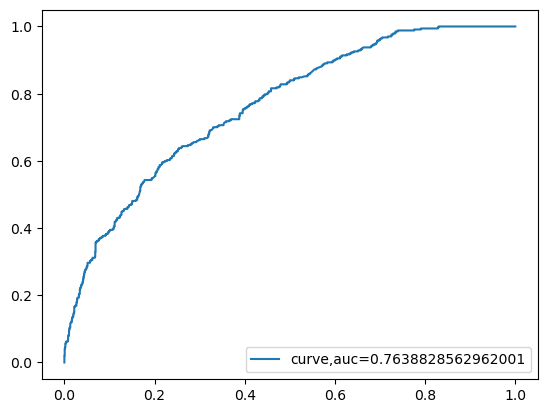

```python
fpr,tpr,_=metrics.roc_curve(Ytest,ypred)
auc=metrics.roc_auc_score(Ytest,ypred)
plt.plot(fpr,tpr,label="curve,auc="+str(auc))
plt.legend(loc=4)
plt.show()
```

# Save as CSV file

```python
data.to_csv('HR analysis.csv',index=False)
```

```python
data
```

|  | DOJ Extended | Duration to accept offer | Notice period | Offered band | Percent difference CTC | Joining Bonus | Candidate relocate actual | Candidate Source | Rex in Yrs | LOB | Status |
| --- | --- | --- | --- | --- | --- | --- | --- | --- | --- | --- | --- |
| 0 | 1 | 14 | 30 | 2 | 7.63 | 0 | 0 | 0 | 7 | 4 | 0 |
| 1 | 0 | 18 | 30 | 2 | 270.00 | 0 | 0 | 2 | 8 | 7 | 0 |
| 2 | 0 | 3 | 45 | 2 | 0.00 | 0 | 0 | 0 | 4 | 7 | 0 |
| 3 | 0 | 26 | 30 | 2 | 0.00 | 0 | 0 | 2 | 4 | 7 | 0 |
| 4 | 1 | 1 | 120 | 2 | 0.00 | 0 | 1 | 2 | 6 | 7 | 0 |
| ... | ... | ... | ... | ... | ... | ... | ... | ... | ... | ... | ... |
| 8990 | 0 | 4 | 0 | 1 | 0.00 | 0 | 0 | 2 | 1 | 4 | 0 |
| 8991 | 1 | 2 | 0 | 1 | 0.00 | 0 | 0 | 1 | 3 | 1 | 0 |
| 8992 | 0 | 0 | 0 | 2 | 0.00 | 0 | 0 | 1 | 5 | 7 | 0 |
| 8993 | 0 | 0 | 30 | 1 | 23.07 | 0 | 0 | 1 | 4 | 7 | 0 |
| 8994 | 0 | 2 | 0 | 1 | 31.16 | 0 | 0 | 2 | 1 | 7 | 0 |

8995 rows × 11 columns